# Analysis of exposures with a neutral discourse context

This notebook analyzes the generalization patterns of novel dative-verb learners based on the factors of exposure contexts which situate the novel verb in a neutral discourse context where only the agent is given. For example:

```
DO: mommy [verbed] me a ball.
PP: mommy [verbed] a ball to me .
```

## Loading Data (code hidden)

```
 Found 500 records...
 Found 1000 records...
 Found 1430 records...
 Imported 1430 records. Simplifying...

 Found 500 records...
 Found 850 records...
 Imported 850 records. Simplifying...

 Found 372 records...
 Imported 372 records. Simplifying...

 Found 255 records...
 Imported 255 records. Simplifying...
```

## Cross Dative Generalization

Investigating alternate-form generalization patterns of the learner when it is exposed to the double object dative vs. prepositional object dative.

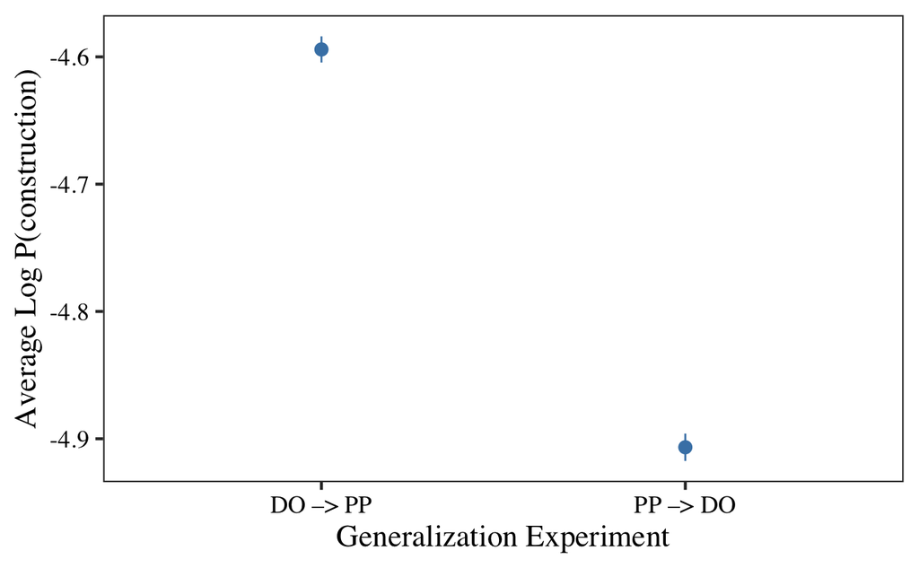

## Conwell’s “me” finding (2019):

Pronominal recipients enable DO comprehension in children, so if we were to believe that comprehension is a precondition to generalization, then pronominal recipients should also encourage generalization:

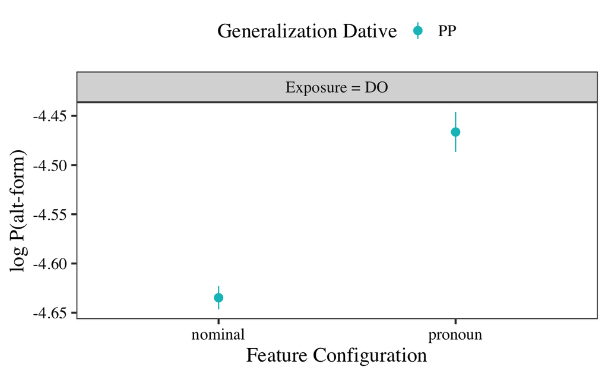

## Replicating Arunachalam (2017):

Only looking at definite themes and recipients:

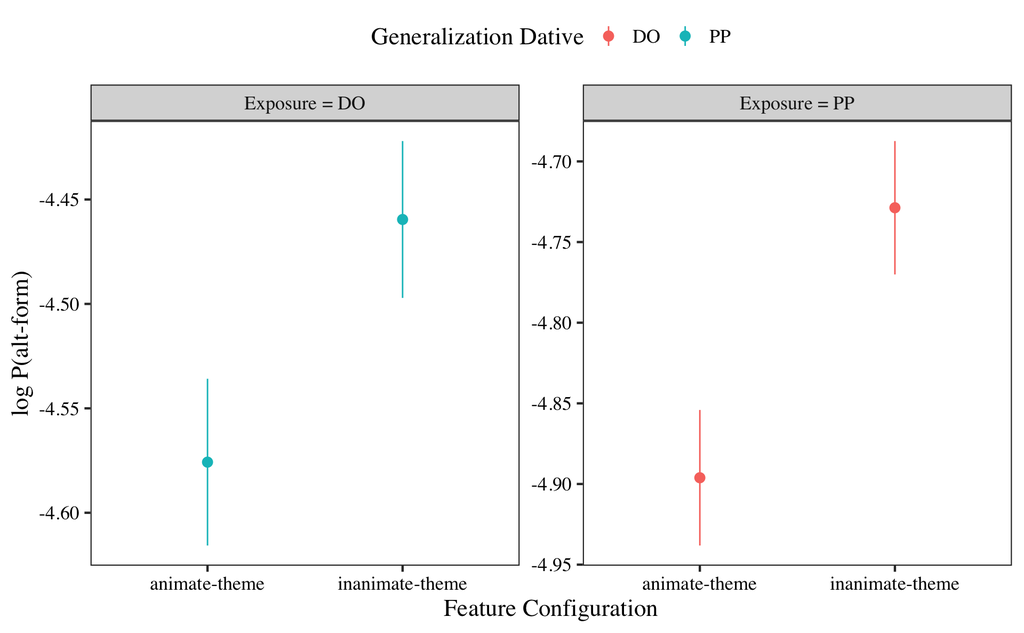

## Interaction terms

The design of interaction terms is a bit tricky. Due to our design, the pronominality might interact with the animacy of a given argument, but animacy and pronominality might also interact across arguments – e.g., if theme is inanimate then LMs might prefer animate recipients (if they are sensitive to the semantics of the dative construction – caused possession/motion). This means we should include the following interaction terms:

```
- theme_animacy * theme_pronominality
- recipient_animacy * recipient_pronominality
- theme_animacy * recipient_animacy
- theme_pronominality * recipient pronominality
```

## DO –> PP analysis

```r
do_pp <- coded_results %>%
  filter(adaptation_dative == "do", generalization_dative == "pp")

# interactions between theme-animacy and recipient animacy; theme-pronominality and recipient-pronominality

fit_tara_tprp_interaction_dopp <- lmer(best ~
                                    theme_animacy + theme_pronominality +
                                    recipient_animacy + recipient_pronominality +
                                    theme_animacy:recipient_animacy +
                                    theme_pronominality:recipient_pronominality +
                                    theme_animacy:theme_pronominality +
                                    recipient_animacy:recipient_pronominality +
                                    theme_definiteness + recipient_definiteness +
                                    theme_length  + recipient_length +
                                    (1|model), data = do_pp)

summary(fit_tara_tprp_interaction_dopp, correlation = FALSE)
```

```
Linear mixed model fit by REML. t-tests use Satterthwaite's method [
lmerModLmerTest]
Formula: best ~ theme_animacy + theme_pronominality + recipient_animacy +
    recipient_pronominality + theme_animacy:recipient_animacy +
    theme_pronominality:recipient_pronominality + theme_animacy:theme_pronominality +
    recipient_animacy:recipient_pronominality + theme_definiteness +
    recipient_definiteness + theme_length + recipient_length +      (1 | model)
   Data: do_pp

REML criterion at convergence: 17834.5

Scaled residuals:
    Min      1Q  Median      3Q     Max
-5.3885 -0.6266  0.1083  0.7250  2.5543

Random effects:
 Groups   Name        Variance Std.Dev.
 model    (Intercept) 0.02339  0.1530
 Residual             0.27701  0.5263
Number of obs: 11400, groups:  model, 10

Fixed effects:
                                              Estimate Std. Error         df
(Intercept)                                 -4.669e+00  5.125e-02  1.111e+01
theme_animacy                               -9.320e-02  1.229e-02  1.138e+04
theme_pronominality                          2.226e-02  1.753e-02  1.138e+04
recipient_animacy                            7.241e-02  1.167e-02  1.138e+04
recipient_pronominality                      1.956e-01  1.738e-02  1.138e+04
theme_definiteness                           3.600e-03  1.001e-02  1.138e+04
recipient_definiteness                       1.231e-01  1.000e-02  1.138e+04
theme_length                                 1.894e-02  1.155e-02  1.138e+04
recipient_length                             6.067e-02  1.178e-02  1.138e+04
theme_animacy:recipient_animacy             -1.141e-01  1.978e-02  1.138e+04
theme_pronominality:recipient_pronominality  1.448e-01  3.365e-02  1.138e+04
theme_animacy:theme_pronominality            2.210e-02  2.459e-02  1.138e+04
recipient_animacy:recipient_pronominality    1.031e-02  2.331e-02  1.138e+04
                                            t value Pr(>|t|)
(Intercept)                                 -91.104  < 2e-16 ***
theme_animacy                                -7.587 3.54e-14 ***
theme_pronominality                           1.270    0.204
recipient_animacy                             6.203 5.74e-10 ***
recipient_pronominality                      11.256  < 2e-16 ***
theme_definiteness                            0.360    0.719
recipient_definiteness                       12.304  < 2e-16 ***
theme_length                                  1.639    0.101
recipient_length                              5.150 2.65e-07 ***
theme_animacy:recipient_animacy              -5.768 8.21e-09 ***
theme_pronominality:recipient_pronominality   4.302 1.71e-05 ***
theme_animacy:theme_pronominality             0.899    0.369
recipient_animacy:recipient_pronominality     0.442    0.658
---
Signif. codes:  0 ‘***’ 0.001 ‘**’ 0.01 ‘*’ 0.05 ‘.’ 0.1 ‘ ’ 1
```

## PP –> DO Analysis

```r
pp_do <- coded_results %>%
  filter(adaptation_dative == "pp", generalization_dative == "do")

fit_tara_tprp_interaction_ppdo <- lmer(best ~
                                    theme_animacy + theme_pronominality +
                                    recipient_animacy + recipient_pronominality +
                                    theme_animacy:recipient_animacy +
                                    theme_pronominality:recipient_pronominality +
                                    theme_animacy:theme_pronominality +
                                    recipient_animacy:recipient_pronominality +
                                    theme_definiteness + recipient_definiteness +
                                    theme_length  + recipient_length +
                                    (1|model), data = pp_do)

summary(fit_tara_tprp_interaction_ppdo, correlation = FALSE)
```

```
Linear mixed model fit by REML. t-tests use Satterthwaite's method [
lmerModLmerTest]
Formula: best ~ theme_animacy + theme_pronominality + recipient_animacy +
    recipient_pronominality + theme_animacy:recipient_animacy +
    theme_pronominality:recipient_pronominality + theme_animacy:theme_pronominality +
    recipient_animacy:recipient_pronominality + theme_definiteness +
    recipient_definiteness + theme_length + recipient_length +      (1 | model)
   Data: pp_do

REML criterion at convergence: 18396.1

Scaled residuals:
    Min      1Q  Median      3Q     Max
-7.3954 -0.6102  0.1257  0.7262  2.5158

Random effects:
 Groups   Name        Variance Std.Dev.
 model    (Intercept) 0.02002  0.1415
 Residual             0.29106  0.5395
Number of obs: 11400, groups:  model, 10

Fixed effects:
                                              Estimate Std. Error         df
(Intercept)                                 -5.150e+00  4.800e-02  1.162e+01
theme_animacy                               -1.686e-01  1.259e-02  1.138e+04
theme_pronominality                          1.954e-01  1.797e-02  1.138e+04
recipient_animacy                           -9.257e-03  1.197e-02  1.138e+04
recipient_pronominality                      9.054e-02  1.781e-02  1.138e+04
theme_definiteness                           4.367e-02  1.026e-02  1.138e+04
recipient_definiteness                       6.893e-02  1.025e-02  1.138e+04
theme_length                                 2.485e-01  1.184e-02  1.138e+04
recipient_length                             1.257e-01  1.208e-02  1.138e+04
theme_animacy:recipient_animacy             -3.004e-02  2.027e-02  1.138e+04
theme_pronominality:recipient_pronominality  1.597e-01  3.449e-02  1.138e+04
theme_animacy:theme_pronominality           -1.371e-01  2.520e-02  1.138e+04
recipient_animacy:recipient_pronominality   -5.158e-02  2.389e-02  1.138e+04
                                             t value Pr(>|t|)
(Intercept)                                 -107.299  < 2e-16 ***
theme_animacy                                -13.385  < 2e-16 ***
theme_pronominality                           10.876  < 2e-16 ***
recipient_animacy                             -0.774   0.4392
recipient_pronominality                        5.084 3.76e-07 ***
theme_definiteness                             4.256 2.10e-05 ***
recipient_definiteness                         6.723 1.87e-11 ***
theme_length                                  20.986  < 2e-16 ***
recipient_length                              10.407  < 2e-16 ***
theme_animacy:recipient_animacy               -1.482   0.1383
theme_pronominality:recipient_pronominality    4.629 3.71e-06 ***
theme_animacy:theme_pronominality             -5.439 5.46e-08 ***
recipient_animacy:recipient_pronominality     -2.159   0.0309 *
---
Signif. codes:  0 ‘***’ 0.001 ‘**’ 0.01 ‘*’ 0.05 ‘.’ 0.1 ‘ ’ 1
```

## Attempt at displaying DO -> PP and PP -> DO in same table:

```r
tidy(fit_tara_tprp_interaction_dopp) %>%
  filter(effect == "fixed") %>%
  select(term, do_pp_estimate = estimate, do_pp_pval = p.value) %>%
  inner_join(
    tidy(fit_tara_tprp_interaction_ppdo) %>%
      filter(effect == "fixed") %>%
      select(term, pp_do_estimate = estimate, pp_do_pval = p.value)
  ) %>%
  mutate(
    # do_pp_estimate = format(do_pp_estimate , scientific=TRUE),
    # pp_do_estimate = format(pp_do_estimate, scientific=TRUE),
    do_pp_estimate = round(do_pp_estimate, 4),
    pp_do_estimate = round(pp_do_estimate, 4),
    do_pp_signif = case_when(
      do_pp_pval < 0.05 ~ "**",
      TRUE ~ as.character(round(do_pp_pval, 4))
    ),
    pp_do_signif = case_when(
      pp_do_pval < 0.05 ~ "**",
      TRUE ~ as.character(round(pp_do_pval, 4))
    )
  ) %>%
  select(term, do_pp_estimate, do_pp_signif, pp_do_estimate, pp_do_signif) %>%
  DT::datatable(options = list(pageLength = 14))
```

|  | term | do_pp_estimate | do_pp_signif | pp_do_estimate | pp_do_signif |
| --- | --- | --- | --- | --- | --- |
| 1 | (Intercept) | -4.6688 | ** | -5.1499 | ** |
| 2 | theme_animacy | -0.0932 | ** | -0.1686 | ** |
| 3 | theme_pronominality | 0.0223 | 0.2041 | 0.1954 | ** |
| 4 | recipient_animacy | 0.0724 | ** | -0.0093 | 0.4392 |
| 5 | recipient_pronominality | 0.1956 | ** | 0.0905 | ** |
| 6 | theme_definiteness | 0.0036 | 0.7192 | 0.0437 | ** |
| 7 | recipient_definiteness | 0.1231 | ** | 0.0689 | ** |
| 8 | theme_length | 0.0189 | 0.1011 | 0.2485 | ** |
| 9 | recipient_length | 0.0607 | ** | 0.1257 | ** |
| 10 | theme_animacy:recipient_animacy | -0.1141 | ** | -0.03 | 0.1383 |

[output cut: 3 more lines]